# Red Wine Quality by Michal Masika

This document presents the final project of Udacity class “Data Analysis with R”. It is the third project of Data Analyst Nanodegree Program. I examine here the quality of red wine. In particular I would like to examine the chemical properties which influence quality of the red wine.

[output not shown]

[output not shown]

[output not shown]

[output not shown]

[output not shown]

[output not shown]

[output not shown]

[output not shown]

[output not shown]

[output not shown]

[output not shown]

[output not shown]

[output not shown]

# Data Overview

In this section I describe the data set used for this analysis. The dataset was used by Cortez et al. (2009). It is related to the red wine variants of the Portugese wine “vinho verde”. It contains information to 1599 variants of red wine.

```
##
##   3   4   5   6   7   8
##  10  53 681 638 199  18
```

```
## [1] 1599   14
```

```
##  [1] "X"                    "fixed.acidity"        "volatile.acidity"
##  [4] "citric.acid"          "residual.sugar"       "chlorides"
##  [7] "free.sulfur.dioxide"  "total.sulfur.dioxide" "density"
## [10] "pH"                   "sulphates"            "alcohol"
## [13] "quality"              "quality.f"
```

```
## 'data.frame':    1599 obs. of  14 variables:
##  $ X                   : int  1 2 3 4 5 6 7 8 9 10 ...
##  $ fixed.acidity       : num  7.4 7.8 7.8 11.2 7.4 7.4 7.9 7.3 7.8 7.5 ...
##  $ volatile.acidity    : num  0.7 0.88 0.76 0.28 0.7 0.66 0.6 0.65 0.58 0.5 ...
##  $ citric.acid         : num  0 0 0.04 0.56 0 0 0.06 0 0.02 0.36 ...
##  $ residual.sugar      : num  1.9 2.6 2.3 1.9 1.9 1.8 1.6 1.2 2 6.1 ...
##  $ chlorides           : num  0.076 0.098 0.092 0.075 0.076 0.075 0.069 0.065 0.073 0.071 ...
##  $ free.sulfur.dioxide : num  11 25 15 17 11 13 15 15 9 17 ...
##  $ total.sulfur.dioxide: num  34 67 54 60 34 40 59 21 18 102 ...
##  $ density             : num  0.998 0.997 0.997 0.998 0.998 ...
##  $ pH                  : num  3.51 3.2 3.26 3.16 3.51 3.51 3.3 3.39 3.36 3.35 ...
##  $ sulphates           : num  0.56 0.68 0.65 0.58 0.56 0.56 0.46 0.47 0.57 0.8 ...
##  $ alcohol             : num  9.4 9.8 9.8 9.8 9.4 9.4 9.4 10 9.5 10.5 ...
##  $ quality             : int  5 5 5 6 5 5 5 7 7 5 ...
##  $ quality.f           : Ord.factor w/ 6 levels "3"<"4"<"5"<"6"<..: 3 3 3 4 3 3 3 5 5 3 ...
```

```
##        X          fixed.acidity   volatile.acidity  citric.acid
##  Min.   :   1.0   Min.   : 4.60   Min.   :0.1200   Min.   :0.000
##  1st Qu.: 400.5   1st Qu.: 7.10   1st Qu.:0.3900   1st Qu.:0.090
##  Median : 800.0   Median : 7.90   Median :0.5200   Median :0.260
##  Mean   : 800.0   Mean   : 8.32   Mean   :0.5278   Mean   :0.271
##  3rd Qu.:1199.5   3rd Qu.: 9.20   3rd Qu.:0.6400   3rd Qu.:0.420
##  Max.   :1599.0   Max.   :15.90   Max.   :1.5800   Max.   :1.000
##  residual.sugar     chlorides       free.sulfur.dioxide
##  Min.   : 0.900   Min.   :0.01200   Min.   : 1.00
##  1st Qu.: 1.900   1st Qu.:0.07000   1st Qu.: 7.00
##  Median : 2.200   Median :0.07900   Median :14.00
##  Mean   : 2.539   Mean   :0.08747   Mean   :15.87
##  3rd Qu.: 2.600   3rd Qu.:0.09000   3rd Qu.:21.00
##  Max.   :15.500   Max.   :0.61100   Max.   :72.00
##  total.sulfur.dioxide    density             pH          sulphates
##  Min.   :  6.00       Min.   :0.9901   Min.   :2.740   Min.   :0.3300
##  1st Qu.: 22.00       1st Qu.:0.9956   1st Qu.:3.210   1st Qu.:0.5500
##  Median : 38.00       Median :0.9968   Median :3.310   Median :0.6200
##  Mean   : 46.47       Mean   :0.9967   Mean   :3.311   Mean   :0.6581
##  3rd Qu.: 62.00       3rd Qu.:0.9978   3rd Qu.:3.400   3rd Qu.:0.7300
##  Max.   :289.00       Max.   :1.0037   Max.   :4.010   Max.   :2.0000
##     alcohol         quality      quality.f
##  Min.   : 8.40   Min.   :3.000   3: 10
##  1st Qu.: 9.50   1st Qu.:5.000   4: 53
##  Median :10.20   Median :6.000   5:681
##  Mean   :10.42   Mean   :5.636   6:638
##  3rd Qu.:11.10   3rd Qu.:6.000   7:199
##  Max.   :14.90   Max.   :8.000   8: 18
```

The datasets contains 1599 observations and 13 variables. The variable of main interest is the quality (with 0 the worst and 10 the best quality). In this dataset, minimum quality is 3 and the maximum quality is 8. Moreover, the mean quality is 5.6 and the median quality is 6. Note that I created a factor variable for quality. All other variables except sulfur.dioxide variables seem to be continuous. The pH lies between 2.7 and 4.01 with mean of 3.311. 75% of wines have alcohol rate smaller than 11.10 %. In the next section I will examine different univariate plots.

# Univariate Plots

First, I provide an overview of distributions of all variables of interest.

[output not shown]

[output not shown]

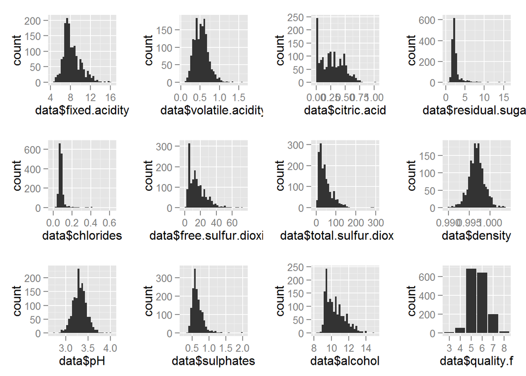

While some of the variables (e.g. ph,quality or density) are normally distributed, there are also variables that are skewed to the right (e.g. residual sugar, acidities or sulfur.dioxides). Next I will examine single variables in more detail. I start with the quality which is the variable of main interest.

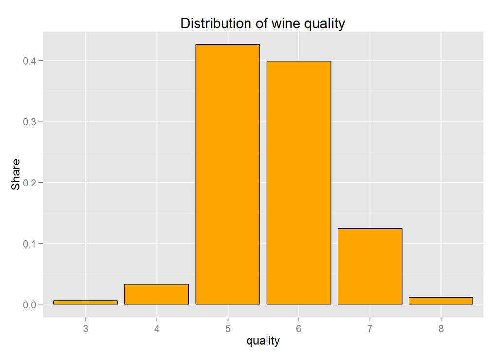

```
##   3   4   5   6   7   8
##  10  53 681 638 199  18
```

Quality is ordered discrete variable. It seems to be normally distributed. More than 80 % of observations have quality equal to 5 or 6. In the next step I look at the distribution of acidity variables.

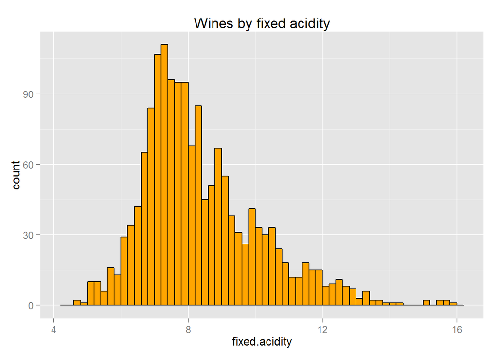

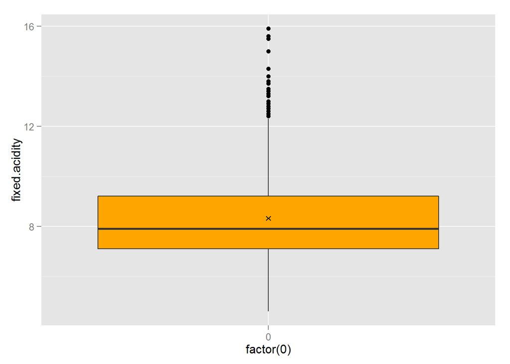

```
##    Min. 1st Qu.  Median    Mean 3rd Qu.    Max.
##    4.60    7.10    7.90    8.32    9.20   15.90
```

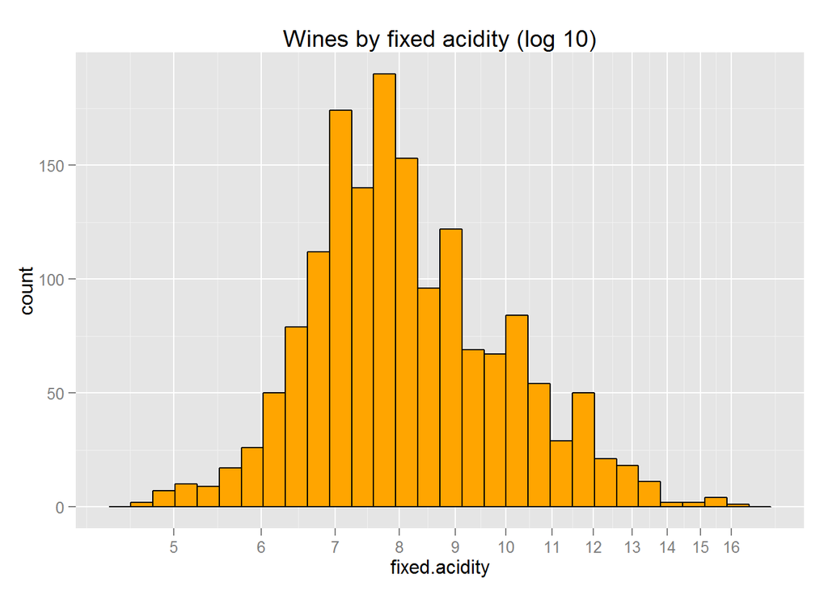

The histogram suggests that the distribution of fixed acidity is skewed to the right. This can be also easily seen in the boxplot for which I created fake grouping variable. The boxplot suggests that there are some outliers with fixed acidity above 12. Therefore, it makes sense to use logarithmic transformation of this variable. By doing this you can see that the distribution becomes normal.

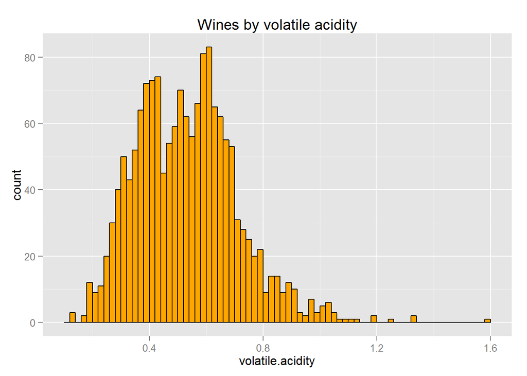

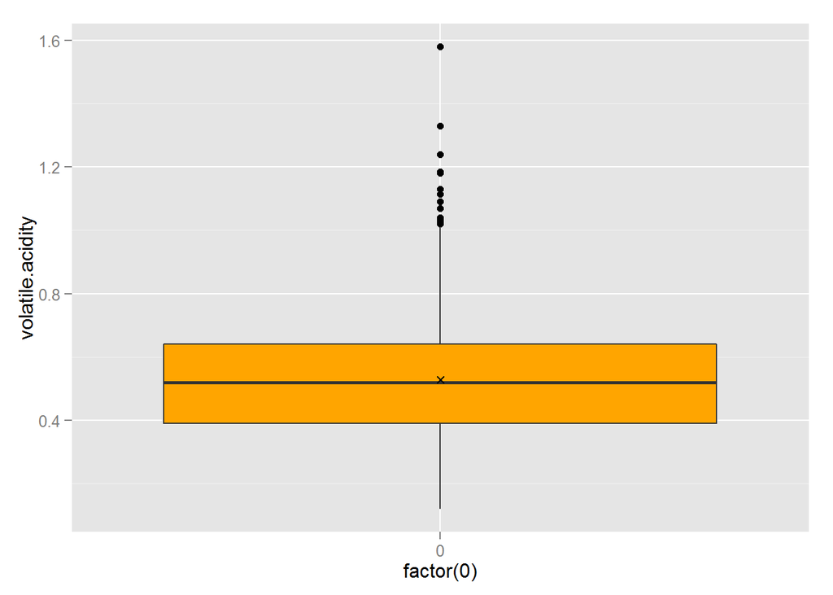

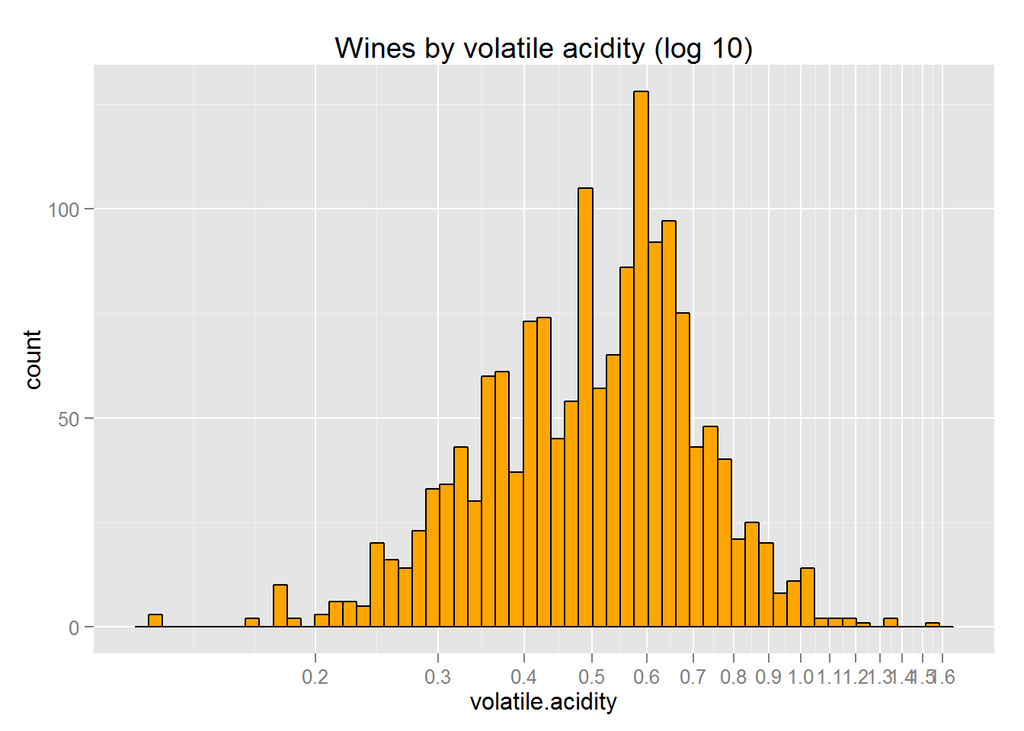

The volatile acidity seems to be skewed to the right as well, but not as extreme as the fixed acidity. There are also some weak outliers. Taking logarithm can help me to shape the distribution more towards normal distribution. The effect is, however, not so strong as by fixed acidity.

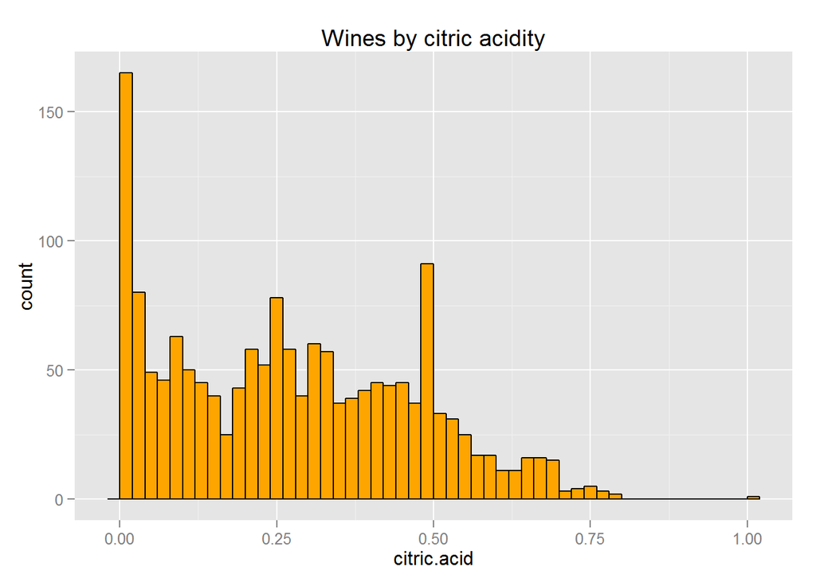

```
## [1] 132
```

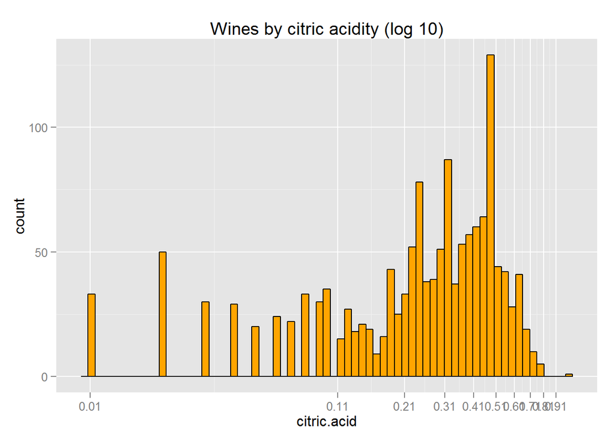

Citric acidity doesn’t seem to be normal distributed at all. A more detailed view indicates that there are 132 observations with no citric accidity. Therefore a logarithmic transformation won’t help that much. The second histogram make use of logarithmic transformation. You can easily see that the distribution doesn’t seem to be normal. Moreover, I am wondering if the single appearance of citric acidity has impact on quality. Therefore, I create a dummy variable indicating the appeareance of citric acidity.

As all three variables measure how acid the wine is, it might be reasonable to aggregate them into one variable - total acidity. In the next step I examine this new variable.

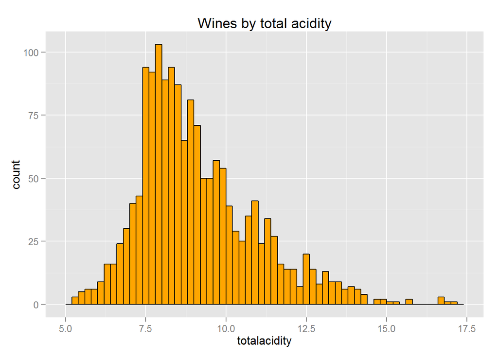

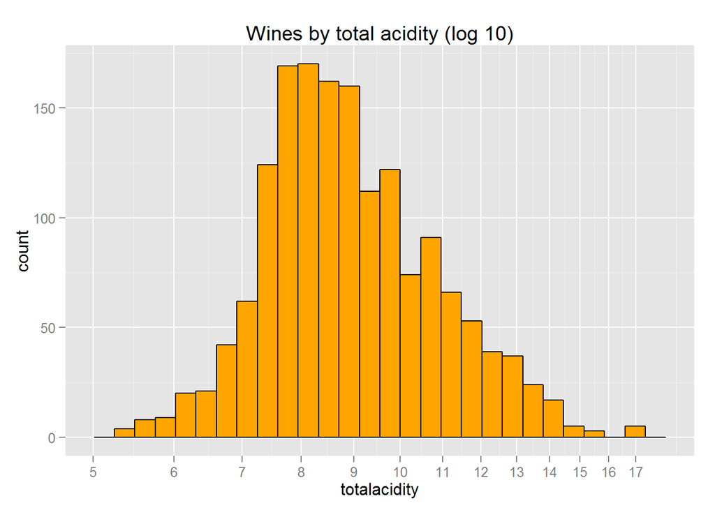

The total acidity is longtailed. Therefore, I decided to take logarithm of it. By doing this the distribution appear to be more normal. In the next step I examine the residual sugar.

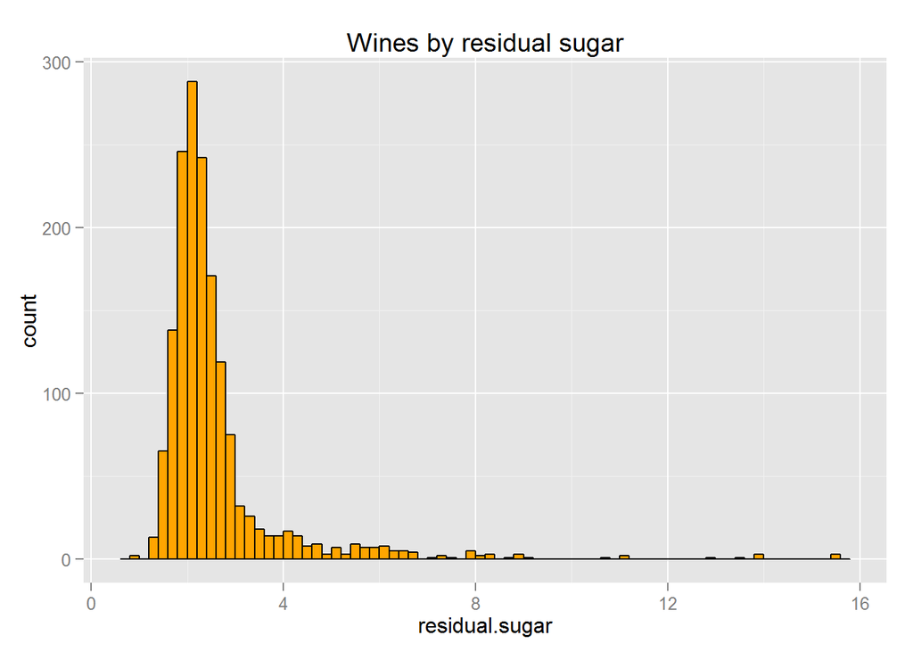

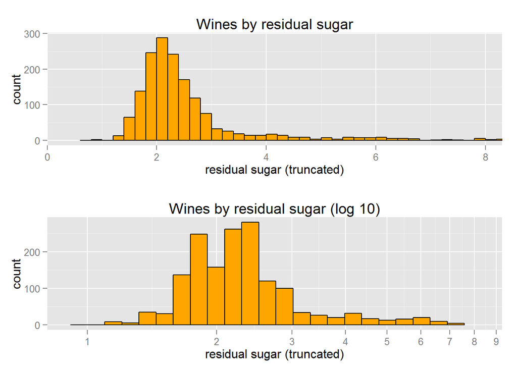

In the next step I examine the chlorides and sulphates.

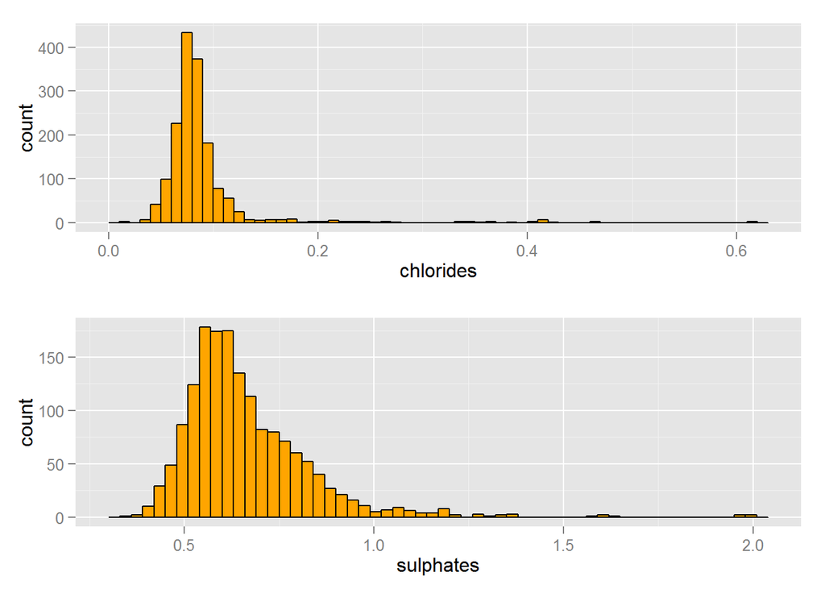

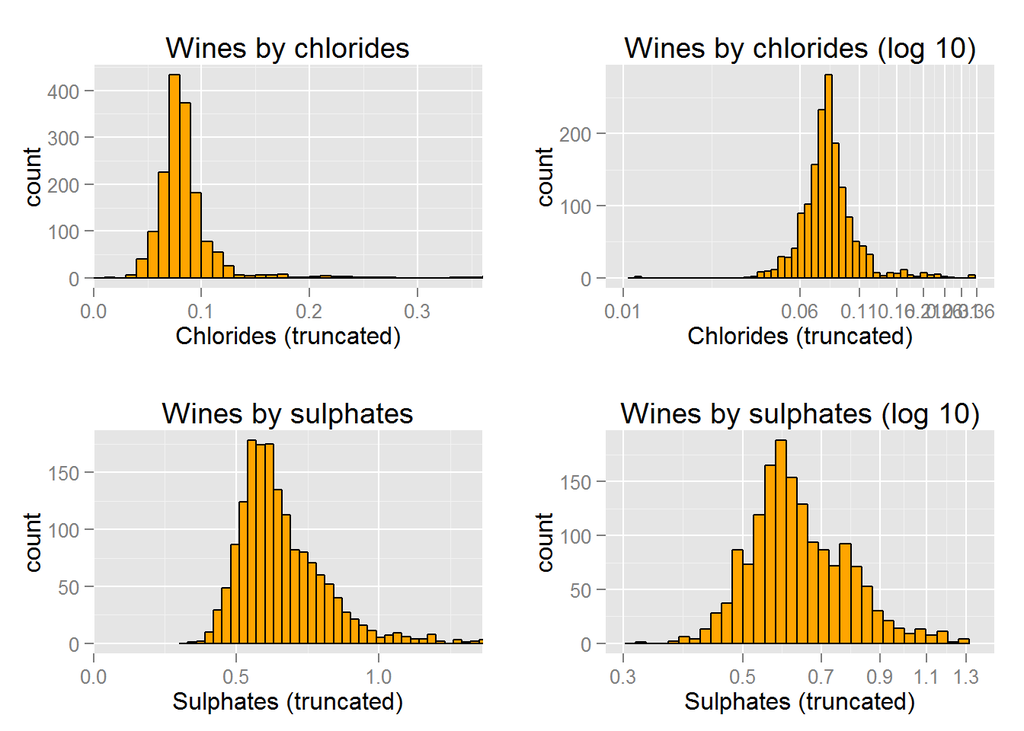

Both chlorides and sulphates are skewed to the right. There are some “extreme” outliers in both cases. Taking logarithm help me to make their distribution normal. In the last step I look at total sulfur dioxide as well as alcohol.

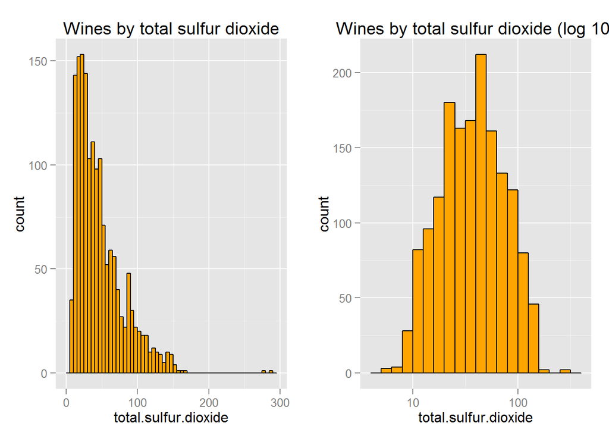

As the distribution of total sulfur dioxide is longtailed I decided to take logarithm of this variable.

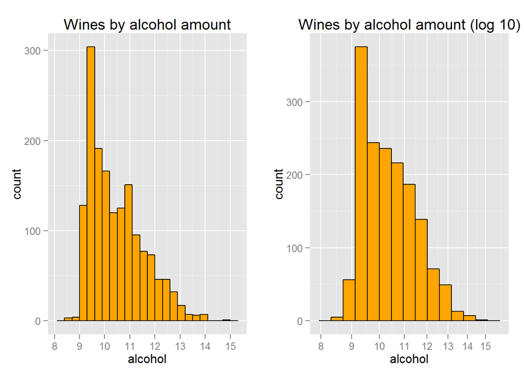

```
##
##   8   9  10  11  12  13  14  15
##   3 294 686 336 210  56  13   1
```

# Univariate Analysis

### What is the structure of your dataset?

There are 1599 observations in the dataset with 13 features which provides information about the chemical content of the wine (e.g. the amount of fixed or volatile acidity or the amount of alcohol) as well as the information about the quality (evaluated by experts). The detailed description of these features can be found in the previous section.

The variable of main interest is the quality, which is an ordered discrete variable between 3 and 8.

(lowest quality) —–> (highest quality)

3 -> 4 -> 5 -> 6 -> 7 -> 8

Moreover, the mean quality is 5.6 and the median quality is 6. Quality is normally distributed. More than 80 % of observations have quality equal to 5 or 6.

Other observations:

The acidity variables seem to be skewed to the right with some outliers. There are 132 observations without any citric acidity. So, the question is whether this is true or just missing data.

Residual sugar, chlorides, total sulfur dioxideand sulphates are also skewed to the right. These variables contain even more extreme outliers than the acidity variables. For example, by more than 5 % of variables the difference between 75th percentile of sulphates variable and the amount of sulphates is larger than IQR of this variable. Similar things can be also observed by other variables (e.g. residual sugar or chlorides). The pH lies between 2.7 and 4.01 with mean of 3.311. The minimum alcohol amount is 8.4%. 75% of wines have alcohol rate smaller than 11.10 %.

### What is/are the main feature(s) of interest in your dataset?

I would like to determine which features are best for predicting the quality of the red wine. The main feature is therefore the quality variable, which is ordered discrete variable from 3 till 8. I suspect that the alcohol variable as well as acidity variables do have an impact on the quality of the wine.

### What other features in the dataset do you think will help support your investigation into your feature(s) of interest?

Besides the amount of alcohol and acidity amount, I think that amount of chlorides or sulphates as well as the density might help me to better predict the quality of red wine.

### Did you create any new variables from existing variables in the dataset?

I just transformed the quality variable into a factor variable. Moreover I created new variable which indicates whether there is a citric acidity or there isn’t. This allows me to examine the effect of appearance of citric acidity on wine quality.

Moreover, there are three variables indicating how acid is the wine. Therefore, I aggregate them into one variable - total acidity. Bivariate analysis (see below) however shows that different types of acidity might have different impact on the quality. Therefore, it might be not that useful to use total acidity to understand better the relationship between quality and acidity.

### Of the features you investigated, were there any unusual distributions? Did you perform any operations on the data to tidy, adjust, or change the form of the data? If so, why did you do this?

AS mentioned earlier distributions of some variables doesn’t seem to be normal (e.g. acidity variables, residual sugar, total sulfur dioxide, sulphates or alcohol). Therefore it might be useful to take logarithm of them to get normal distribution. This might be in particular important for variables with extreme outliers like sulphates, chlorides or residual sugar. I didn’t perform any other changes to the data.

# Bivariate Plots Section

[output not shown]

[output not shown]

[output not shown]

[figure not shown]

```
##        fixed.acidity     volatile.acidity          citric.acid
##           0.12405165          -0.39055778           0.22637251
##       residual.sugar            chlorides  free.sulfur.dioxide
##           0.01373164          -0.12890656          -0.05065606
## total.sulfur.dioxide              density                   pH
##          -0.18510029          -0.17491923          -0.05773139
##            sulphates              alcohol              quality
##           0.25139708           0.47616632           1.00000000
##         totalacidity
##           0.10375373
```

Both the figure and the correlation matrix suggest that higher quality is connected with:

- higher citric acidity, lower volatile acidity
- lower total sulfur dioxide
- lower density
- higher sulpates and
- higher alcohol

- higher fixed acidity
- lower chlorides

In the next step, I examine the relationship between acidity variables and quality in more detail.

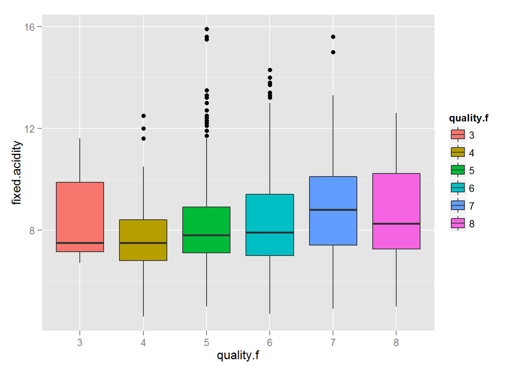

```
## geom_smooth: method="auto" and size of largest group is >=1000, so using gam with formula: y ~ s(x, bs = "cs"). Use 'method = x' to change the smoothing method.
```

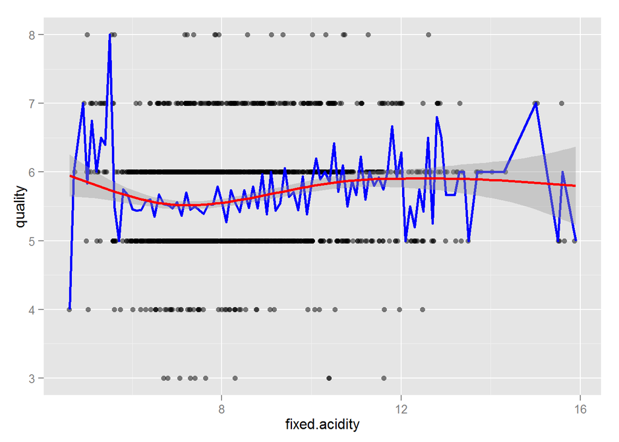

```
##
##  Pearson's product-moment correlation
##
## data:  quality and fixed.acidity
## t = 4.996, df = 1597, p-value = 6.496e-07
## alternative hypothesis: true correlation is not equal to 0
## 95 percent confidence interval:
##  0.07548957 0.17202667
## sample estimates:
##       cor
## 0.1240516
```

There doesn’t seem to be strong relationship between fixed acidity and quality. The correlation is pretty low (0.12).

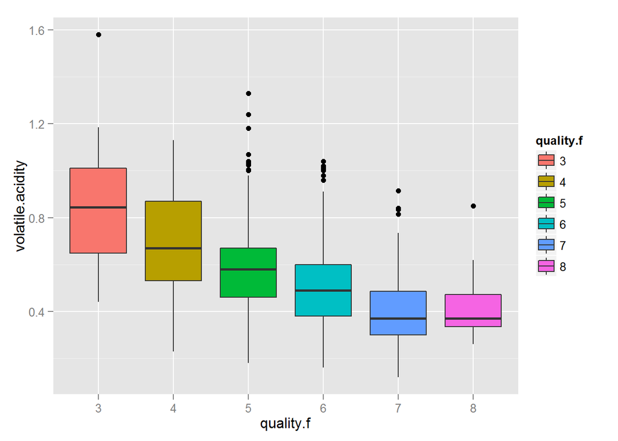

```
## geom_smooth: method="auto" and size of largest group is >=1000, so using gam with formula: y ~ s(x, bs = "cs"). Use 'method = x' to change the smoothing method.
```

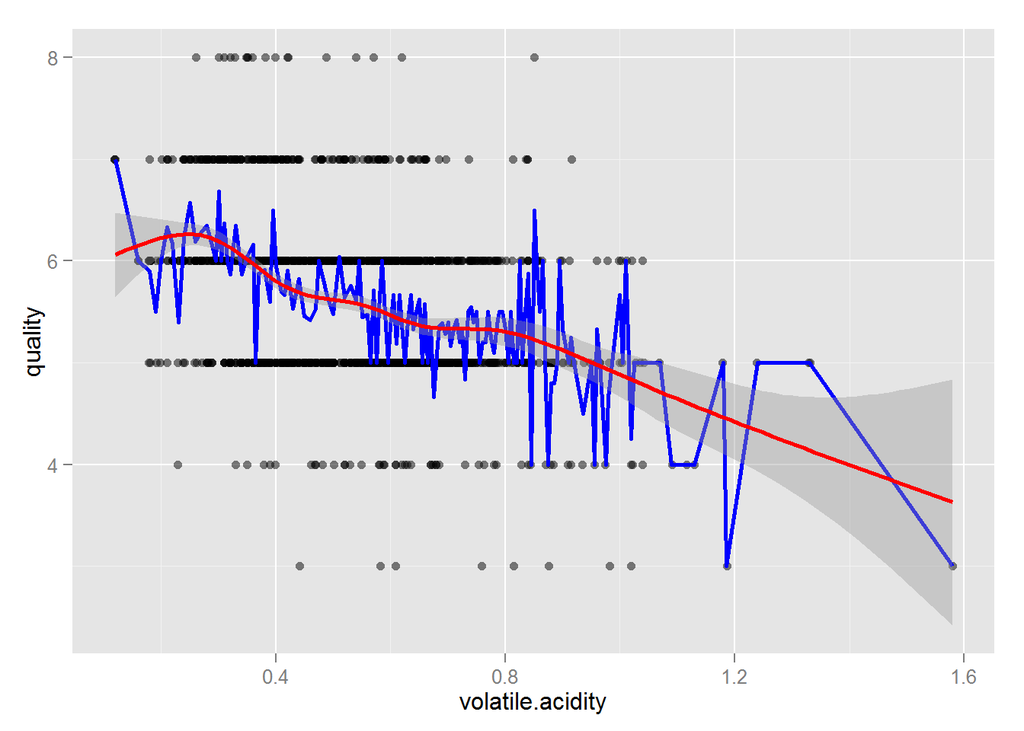

```
##
##  Pearson's product-moment correlation
##
## data:  quality and volatile.acidity
## t = -16.954, df = 1597, p-value < 2.2e-16
## alternative hypothesis: true correlation is not equal to 0
## 95 percent confidence interval:
##  -0.4313210 -0.3482032
## sample estimates:
##        cor
## -0.3905578
```

Both figures suggest that there is a negative relationship between volatile acidity and quality. The correlation is almost - 0.4.

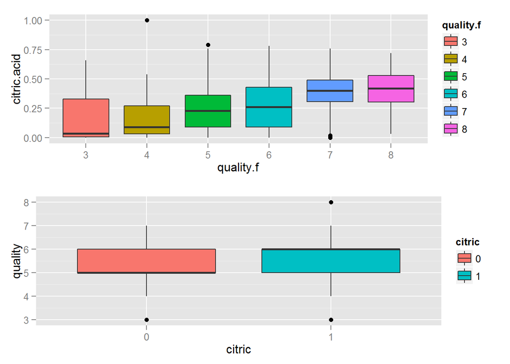

```
## data$citric: 0
##    Min. 1st Qu.  Median    Mean 3rd Qu.    Max.
##   3.000   5.000   5.000   5.409   6.000   7.000
## --------------------------------------------------------
## data$citric: 1
##    Min. 1st Qu.  Median    Mean 3rd Qu.    Max.
##   3.000   5.000   6.000   5.656   6.000   8.000
```

```
## geom_smooth: method="auto" and size of largest group is >=1000, so using gam with formula: y ~ s(x, bs = "cs"). Use 'method = x' to change the smoothing method.
```

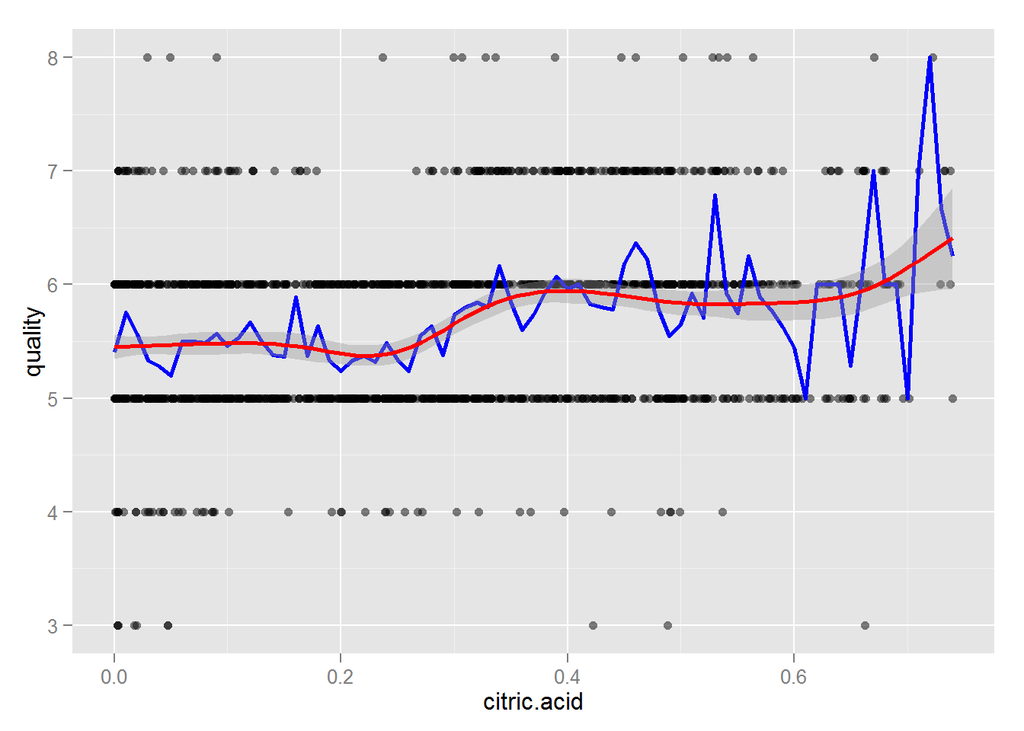

```
##
##  Pearson's product-moment correlation
##
## data:  quality and citric.acid
## t = 9.2875, df = 1597, p-value < 2.2e-16
## alternative hypothesis: true correlation is not equal to 0
## 95 percent confidence interval:
##  0.1793415 0.2723711
## sample estimates:
##       cor
## 0.2263725
```

```
## geom_smooth: method="auto" and size of largest group is >=1000, so using gam with formula: y ~ s(x, bs = "cs"). Use 'method = x' to change the smoothing method.
```

```
## geom_smooth: method="auto" and size of largest group is >=1000, so using gam with formula: y ~ s(x, bs = "cs"). Use 'method = x' to change the smoothing method.
```

```
## geom_smooth: method="auto" and size of largest group is >=1000, so using gam with formula: y ~ s(x, bs = "cs"). Use 'method = x' to change the smoothing method.
```

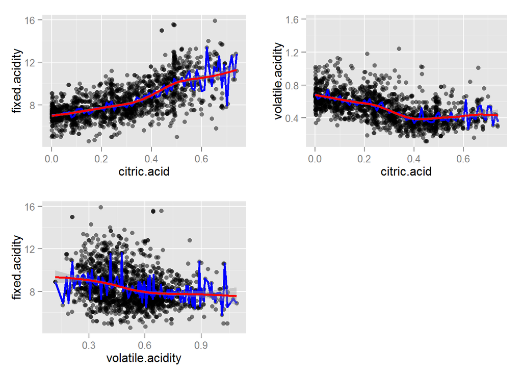

There is pretty strong positive relationship between fixed and citric acidity. The relationship between citric and volatile acidity is negative. However, it seems to flatten by higher citric acidity. Finnally, higher fixed acidity seems to be connected with lower volatile acidity. This relationship is not that strong.

As pH is a measure of acidity, I would expect strong relationship between pH and acidity variables. This is examined as next.

```
## geom_smooth: method="auto" and size of largest group is >=1000, so using gam with formula: y ~ s(x, bs = "cs"). Use 'method = x' to change the smoothing method.
```

```
## geom_smooth: method="auto" and size of largest group is >=1000, so using gam with formula: y ~ s(x, bs = "cs"). Use 'method = x' to change the smoothing method.
```

```
## geom_smooth: method="auto" and size of largest group is >=1000, so using gam with formula: y ~ s(x, bs = "cs"). Use 'method = x' to change the smoothing method.
```

```
## geom_smooth: method="auto" and size of largest group is >=1000, so using gam with formula: y ~ s(x, bs = "cs"). Use 'method = x' to change the smoothing method.
```

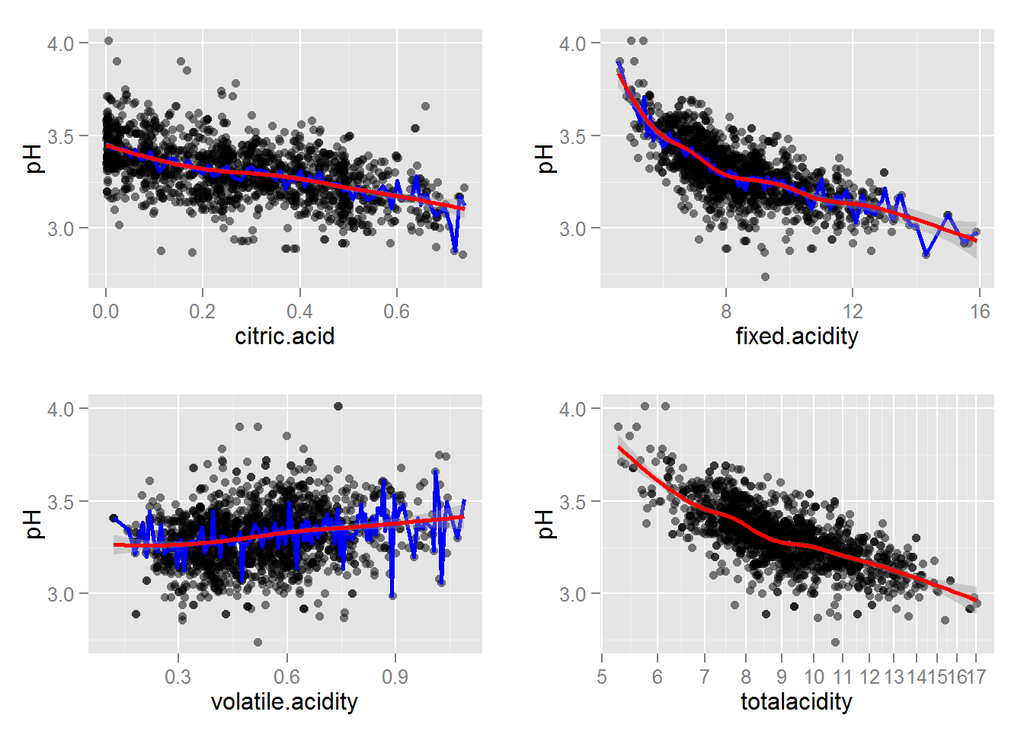

In genereal holds, the lower pH the higher acidity. This can be observed by citric, fixed acidity and the newly generated total acidity. However, the correlation between pH and volatile acidity is positive suggesting that not all acidity types have the same influence on the pH.

In the next figures I examine the relationship between sulphates and quality.

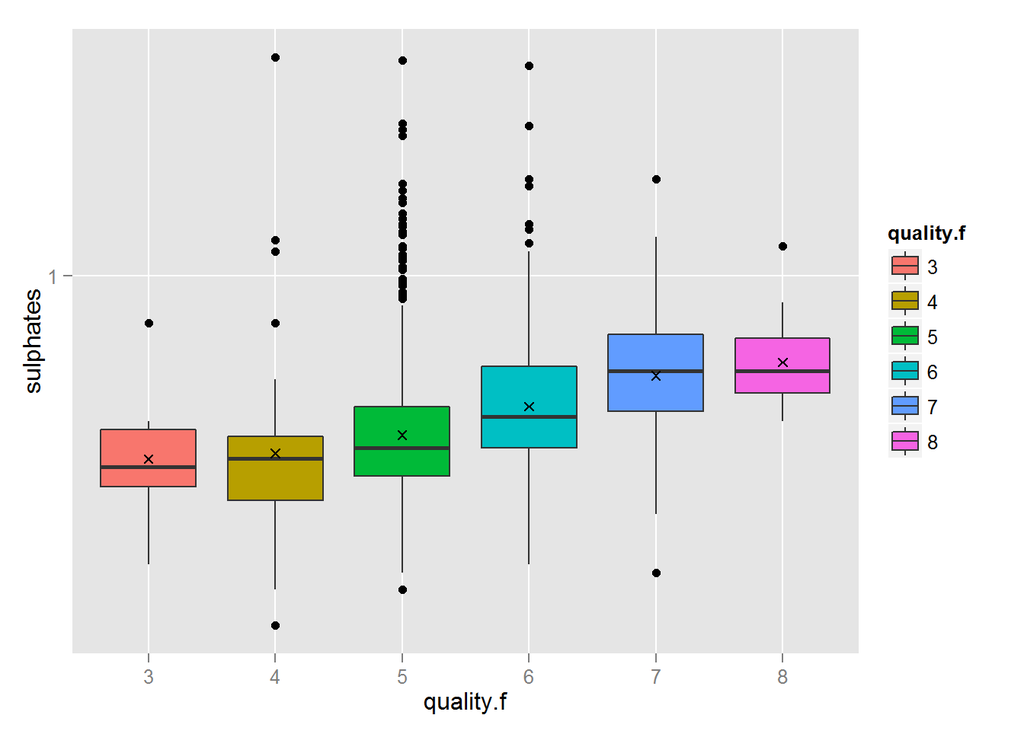

```
## geom_smooth: method="auto" and size of largest group is >=1000, so using gam with formula: y ~ s(x, bs = "cs"). Use 'method = x' to change the smoothing method.
```

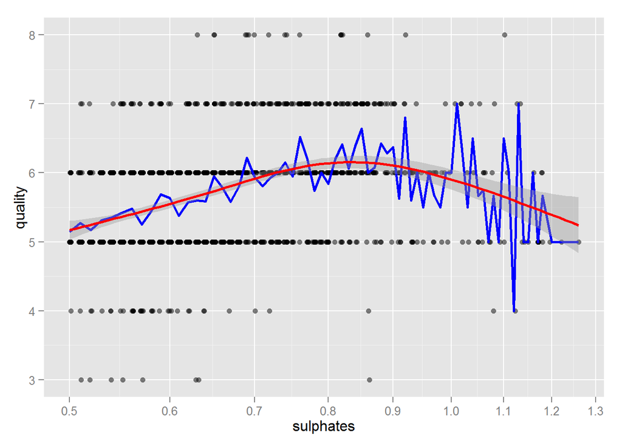

```
##
##  Pearson's product-moment correlation
##
## data:  quality and log10(sulphates)
## t = 12.967, df = 1597, p-value < 2.2e-16
## alternative hypothesis: true correlation is not equal to 0
## 95 percent confidence interval:
##  0.2636092 0.3523323
## sample estimates:
##       cor
## 0.3086419
```

Although the correlation between log sulphates and the quality is not that weak (0.31), the figure suggests that the relationship between those two variables might not be linear. It might be useful to add into the model squared log of sulphates. I am wondering if a similar relationship can be observed also between total sulfur dioxide and the quality.

```
## geom_smooth: method="auto" and size of largest group is >=1000, so using gam with formula: y ~ s(x, bs = "cs"). Use 'method = x' to change the smoothing method.
```